# TimingSDS8

2022-06-30

### Overdispersion of mutation counts in normal blood

We estimate the expected overdispersion, here measured as the ratio of observed variance to Poisson variance, as a function of age using burdens from normal blood single cell derived colonies reported in Mitchell et al.

```r
dat=read.table("~/Downloads/normal_haematopoiesis-main/3_mutation_telomere_analysis/input/Summary_cut.csv",sep=",",header = TRUE)
res=dat %>% group_by(donor_id,age) %>% summarise(nsub=mean(sub_adj),vsub=var(sub_adj),N=n())
```

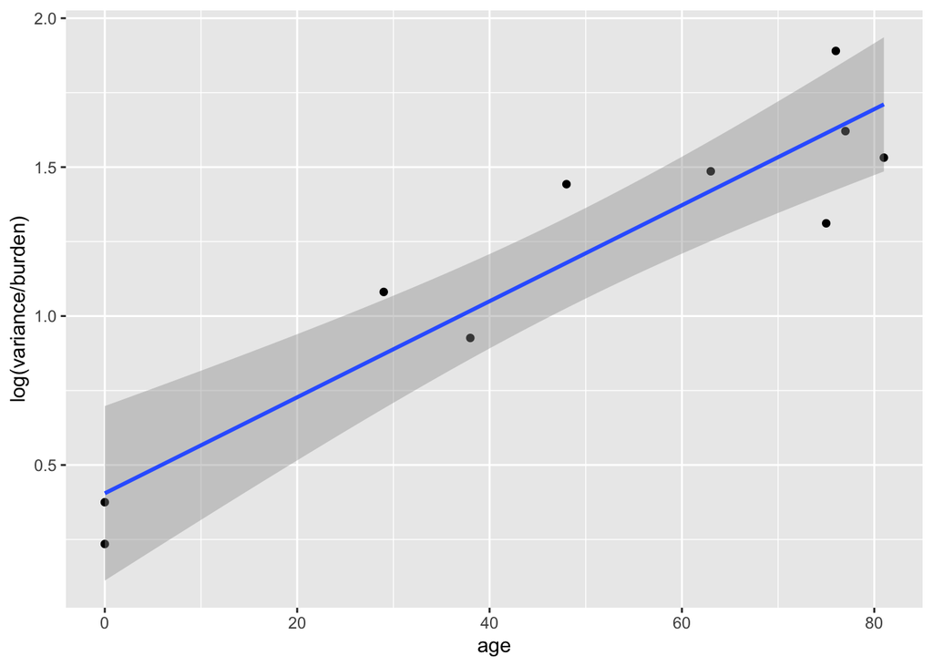

```r
res %>% ggplot(aes(x=age,y=log(vsub/nsub)))+geom_point()+ylab("log(variance/burden)")+geom_smooth(method="lm")
```

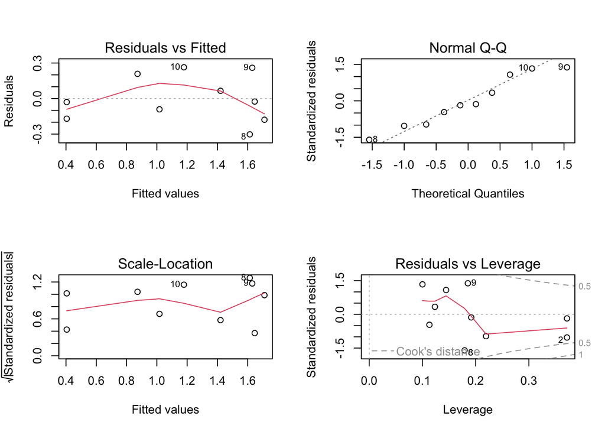

```r
lm=lm(data=res %>% mutate(od=vsub/nsub),log(od)~age)
par(mfrow=c(2,2))
plot(lm)
```

```r
lod.pred=predict(lm,data.frame(age=25),interval = "confidence")
print(exp(lod.pred))
```

```
##        fit      lwr      upr
## 1 2.243254 1.846185 2.725723
```

```r
od.pred=exp(lod.pred[,"fit"]) ## convert back to OD as we did log-linear regression
cat("predicted variance/burden=od=",od.pred)
```

```
## predicted variance/burden=od= 2.243254
```

```r
maxod=exp(lod.pred[,"upr"])
cat("predicted max variance/burden=od=",maxod)
```

```
## predicted max variance/burden=od= 2.725723
```

```r
ODF=od.pred
ODF_MAX=maxod
```

## Retrieve tree data for individuals

```r
pdd_cache="../cache/PDD.RDS"
PDD=readRDS(pdd_cache)
```

## Retrieve SNVs called for representative SDS patients of the similar age to SDS8 (SDS6,7 and 9) (“NormalSBS” signature)

```r
normal_snvs=do.call("rbind",
                    lapply(c("SDS6","SDS7","SDS9"),
                           function(x) PDD[[x]]$pdx$dat$details %>%
                             filter(TYPE=="SNV" & is_localx_excluded==0) %>%
                             dplyr::select(1:6)))
normal_mut_matrix=with(normal_snvs,get_mut_matrix(Chrom,Pos,Ref,Alt))
```

## Retrieve SNVs that map to after acquistion (“MutantCloneSBS” signature) and also those on the trunk (“TrunkSBS”)

Get all child branches of node 13 (see plot below):

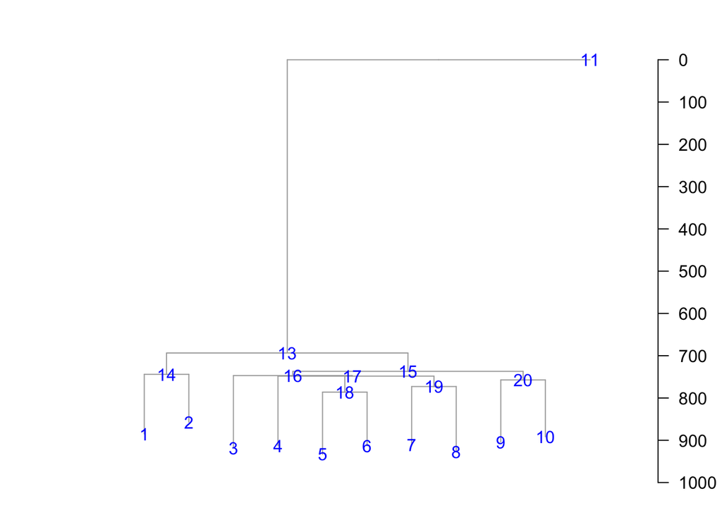

```r
tt=plot_tree(PDD$SDS8$pdx$tree_ml,cex.label = 0)
node_labels(tt,b_include_tips = TRUE)
```

```r
TRUNKNODE=13
nodes=get_all_node_children(TRUNKNODE,PDD$SDS8$pdx$tree_ml)
cat(nodes,"\n")
```

```
## 14 15 1 2 16 20 3 17 4 18 19 5 6 7 8 9 10
```

```r
mutant_clone_snvs=PDD$SDS8$pdx$dat$details %>% filter(TYPE=="SNV" & is_localx_excluded==0 & node %in% nodes )
mt_mut_matrix=with(mutant_clone_snvs,get_mut_matrix(Chrom,Pos,Ref,Alt))
trunk_snvs=PDD$SDS8$pdx$dat$details %>% filter(TYPE=="SNV" & is_localx_excluded==0 & node==TRUNKNODE)
trunk_mut_matrix=with(trunk_snvs,get_mut_matrix(Chrom,Pos,Ref,Alt))
cat("Found",nrow(trunk_snvs),"SNVs in non-masked regions on the trunk\n")
```

```
## Found 559 SNVs in non-masked regions on the trunk
```

## The signatures are clearly quite different

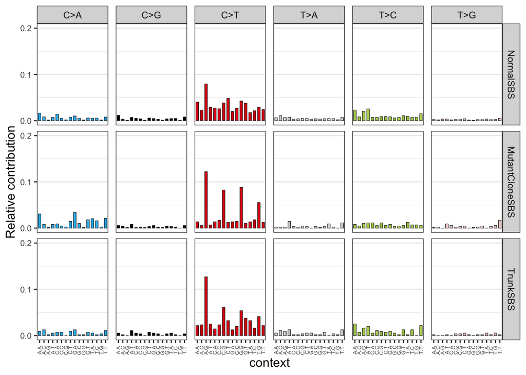

```r
mutmat=cbind(normal_mut_matrix,mt_mut_matrix,trunk_mut_matrix)
colnames(mutmat)=c("NormalSBS","MutantCloneSBS","TrunkSBS")
plot_96_profile(mutmat)
```

```r
csm=cos_sim_matrix(mutmat,mutmat)
print(csm)
```

```
##                NormalSBS MutantCloneSBS  TrunkSBS
## NormalSBS      1.0000000      0.8198108 0.9335218
## MutantCloneSBS 0.8198108      1.0000000 0.9026947
## TrunkSBS       0.9335218      0.9026947 1.0000000
```

## Estimate the Proportion of trunk SNVs that carry the “normal” signature

Decompose “TrunkSBS” into a sum of “NormalSBS” and “MutantCloneSBS”. The number trunk variants attributed to “NormalSBS” gives a direct estimate of the mutation burden at transformation and hence an estimate of the timing of transformation:

```r
## normalise counts
mutmatn=t(apply(mutmat,1,"/",colSums(mutmat)))
##  Fit sit to signature using SigFit
mcmcfit <- sigfit::fit_signatures(
  counts = t(mutmat[,"TrunkSBS",drop=FALSE]),
  signatures = t(mutmatn[,c("NormalSBS","MutantCloneSBS")]),
  iter = 10000,warmup = 5000,chains = 1,seed = 1234567)
```

```
## ---
## Fitting 2 signatures using multinomial model
## ---
## Stan sampling:
```

```r
exposures=retrieve_pars(mcmcfit,par="exposures",hpd_prob=0.95)
print(exposures)
```

```
## $mean
##          NormalSBS MutantCloneSBS
## TrunkSBS   0.80073        0.19927
##
## $lower_95
##          NormalSBS MutantCloneSBS
## TrunkSBS 0.6869367     0.08204376
##
## $upper_95
##          NormalSBS MutantCloneSBS
## TrunkSBS 0.9179562      0.3130633
```

```r
## get approx standard error for subsequent use.
se.approx=(exposures$upper_95["NormalSBS"]-exposures$lower_95["NormalSBS"])/(2*1.96)
```

Reconstruction :

```
## Building reconstructed catalogues...
## Plotting reconstructed catalogues...
```

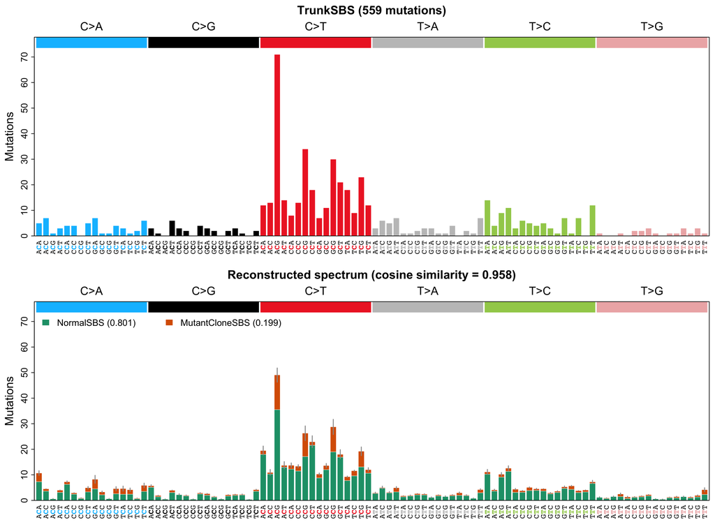

```r
par(mar=c(5,6,6.5,1))
plot_reconstruction(mcmcfit)
```

## Convert the above into an estimate of the mutaton timing

The number trunk variants attributed to “NormalSBS” gives a direct estimate of the mutation burden at transformation and hence an estimate of the timing of transformation. We account for the intrinsic stochastic number of mutations acquired by a single cell at a given age using a simple ABC model that assumes the number of mutations acquired is negative binomial distributed with a mean that is itself uncertain because the mutation rate differs between individuals (random effect):

```r
SLOPE=15.08998
INTERCEPT=118.93678
N_TRUNK_MUTS=693.5  # Adjusted mutation burden of trunk.
SLOPE_SD=1
PNORMAL_SBS=as.numeric(exposures$mean["NormalSBS"])
PNORMAL_SBS_SE=as.numeric((exposures$upper_95["NormalSBS"]-exposures$lower_95["NormalSBS"])/(2*1.96)) ## approx stand error.

lb.trunk.muts=N_TRUNK_MUTS*as.numeric(exposures$lower_95["NormalSBS"])
ub.trunk.muts=N_TRUNK_MUTS*as.numeric(exposures$upper_95["NormalSBS"])
cat(sprintf("Number of mutations attributed to NormalsSBS %4.1f (%4.1f-%4.1f)",N_TRUNK_MUTS*PNORMAL_SBS,lb.trunk.muts,ub.trunk.muts))
```

```
## Number of mutations attributed to NormalsSBS 555.3 (476.4-636.6)
```

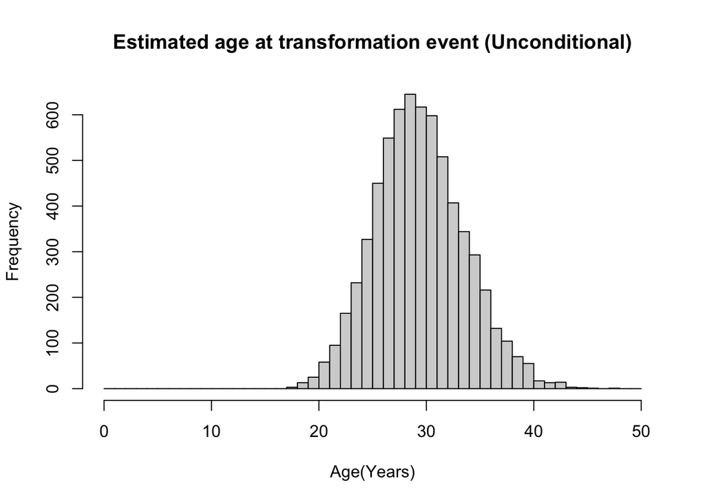

```r
set.seed(1234567)
timing.abc=function( N=1e6,T=25){
  t0=runif(N,0,T)
  lambda=rnorm(N,SLOPE,SLOPE_SD)
  intercept=INTERCEPT
  od=ODF ##  This is age specific estimate based on the normal patients in Mitchell et al.
  nsub=rnbinom(N,mu=lambda*t0+INTERCEPT,size=(lambda*t0+INTERCEPT)/(od-1))
  nsub_sbs=round(N_TRUNK_MUTS*rtrunc(N,"norm",mean=PNORMAL_SBS,sd=PNORMAL_SBS_SE,a=0,b=1))
  data.frame(nsub=nsub,nsub_sbs=nsub_sbs,t0=t0,lambda=lambda)
}
## Unconditional timing ()
test=timing.abc(N=1e7,T=100)
after.rejection.sampling=test %>% filter(nsub_sbs==nsub)
hist(after.rejection.sampling$t0,xlab="Age(Years)",main="Estimated age at transformation event (Unconditional)",breaks=seq(0,50,1))
```

```r
cat("Number of samples after rejection sampling",dim(after.rejection.sampling)[1],"\n")
```

```
## Number of samples after rejection sampling 6569
```

```r
print(quantile(after.rejection.sampling$t0,prob=c(0.025,0.5,0.975)))
```

```
##     2.5%      50%    97.5%
## 21.77116 29.17791 38.13314
```

```r
## Unconditional timing ()
test=timing.abc(N=1e7,T=25)
after.rejection.sampling=test %>% filter(nsub_sbs==nsub)
cat("Number of samples after rejection sampling",dim(after.rejection.sampling)[1],"\n")
```

```
## Number of samples after rejection sampling 3923
```

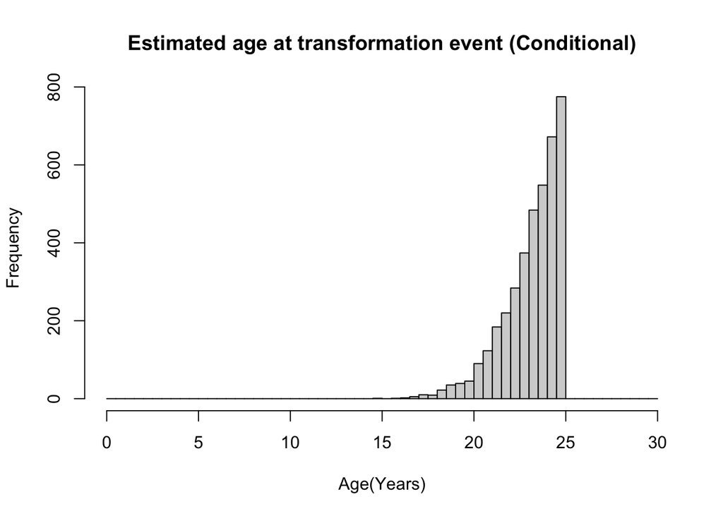

```r
hist(after.rejection.sampling$t0,xlab="Age(Years)",main="Estimated age at transformation event (Conditional)",breaks=seq(0,30,0.5))
```

```r
Q=quantile(after.rejection.sampling$t0,prob=c(0.025,0.5,0.975))
print(Q)
```

```
##     2.5%      50%    97.5%
## 19.22653 23.54306 24.94156
```

```r
age.lower.bound=Q[1]+0.728268  ## Add in the typical post conception age at birth.
age.median=Q[2]+0.728268  ## Add in the typical post conception age at birth.
```

### Estimation using phylofit

We fit the ultrametric tree to the lowest likely age based on the data. We introduce dummy samples so that we can localise the transformation event on a branch and fit the model accordingly.

```r
nwstring=sprintf("((z:0,(z2:0,((b:141.0861791,d:113.2765587):50.45165081,((e:171.1492835,(g:164.5258234,(l:146.9439476,h:127.3626109):37.79341449,(i:137.4571178,k:154.9838747):24.59773156):1.256354434):10.00149207,(f:146.7538421,j:134.5303749):20.28401602):43.5048024):%4.3f):0):%4.3f,zeros:0);",N_TRUNK_MUTS*(1-PNORMAL_SBS),N_TRUNK_MUTS*PNORMAL_SBS)
mt=read.tree(text=nwstring)
mt$agedf=data.frame(tip.label=mt$tip.label)
mt$agedf$age=c(age.lower.bound,age.lower.bound+1e-6,rep(25.728268,10),1e-6)
mt$edge.length=round(mt$edge.length)
ft=fit_tree(mt,switch_nodes = c(16),model="poisson_tree")
```

```
## Median lambda estimate=35.49
```

```r
par(mfcol=c(1,3))
plot_tree(PDD$SDS8$pdx$tree_ml);title("Original Tree")
```

```
##
## Phylogenetic tree with 11 tips and 9 internal nodes.
##
## Tip labels:
##   b, d, e, g, l, h, ...
##
## Rooted; includes branch lengths.
```

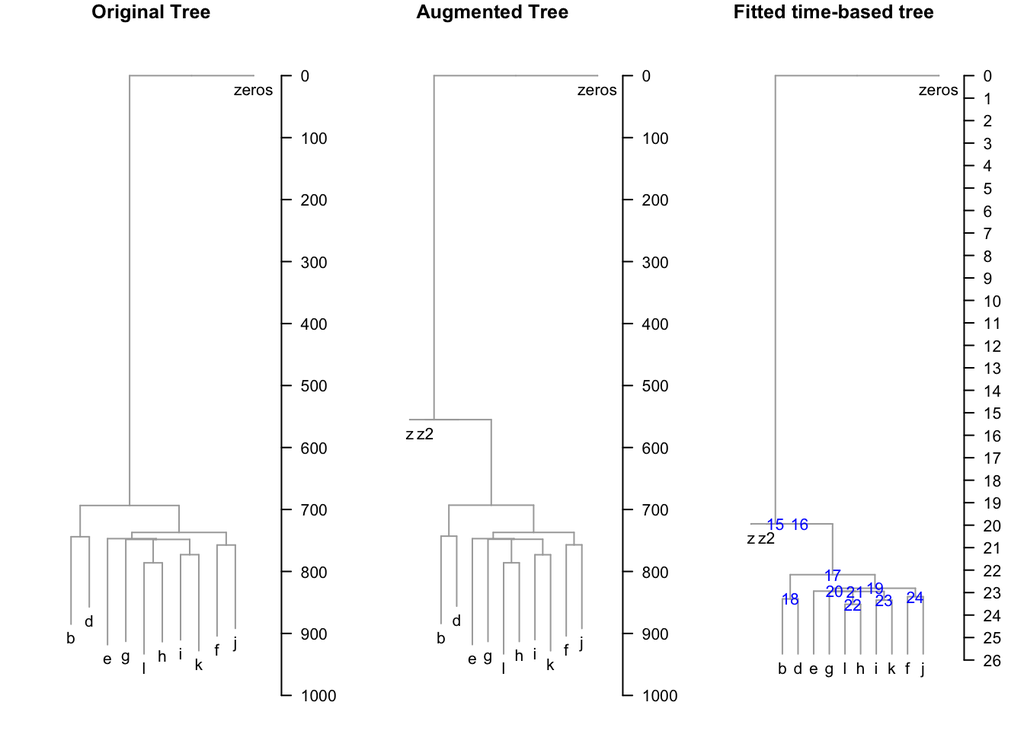

```r
tt=plot_tree(mt);title("Augmented Tree")
tt=plot_tree(ft$ultratree);title("Fitted time-based tree")
node_labels(tt)
```

We now estimate the selection using phylofit on the clade defined by node 17

```r
phylofit_early=fit_clade(ft$ultratree,node=17,nmutcolony = 10,nwtcolony =0,maxt=25.728,maxSYear = 20000,stan.control = list(adapt_delta=0.99))
```

```
## maxt= 25.728 mint= 0
```

```r
print(phylofit_early$res)
```

```
## Inference for Stan model: phylofit.
## 3 chains, each with iter=20000; warmup=10000; thin=1;
## post-warmup draws per chain=10000, total post-warmup draws=30000.
##
##         mean se_mean    sd  2.5%   25%   50%   75%  97.5% n_eff Rhat
## s       3.80    0.00  0.57  2.75  3.40  3.77  4.16   4.99 15830    1
## tm     24.45    0.01  0.59 23.06 24.12 24.55 24.88  25.33 13206    1
## LN      4.75    0.00  0.53  4.03  4.29  4.65  5.13   5.87 18153    1
## offset -1.36    0.01  0.70 -2.84 -1.82 -1.32 -0.88  -0.10 12235    1
## S      51.88    0.31 36.78 14.59 28.96 42.47 63.25 145.77 14196    1
## lp__    4.08    0.02  1.63 -0.09  3.30  4.46  5.27   6.07  6985    1
##
## Samples were drawn using NUTS(diag_e) at Wed Jul 27 09:53:41 2022.
## For each parameter, n_eff is a crude measure of effective sample size,
## and Rhat is the potential scale reduction factor on split chains (at
## convergence, Rhat=1).
```

### Selection estimate based on median age of transformation

```r
mt$agedf$age=c(age.median,age.median+1e-6,rep(25.728268,10),1e-6)
ft2=fit_tree(mt,switch_nodes = c(16),model="poisson_tree")
```

```
## Median lambda estimate=35.49
```

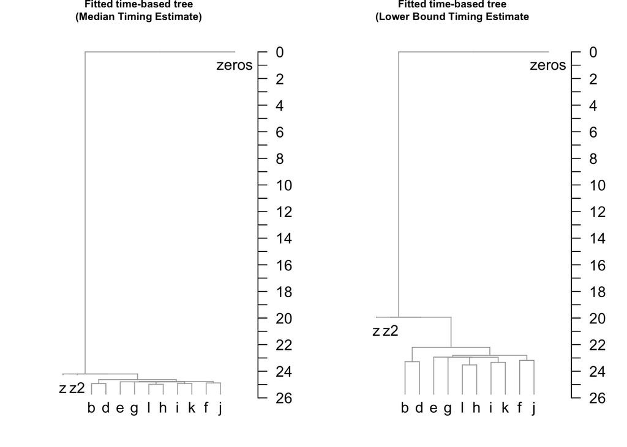

```r
par(mfcol=c(1,2))
tt=plot_tree(ft2$ultratree);title("Fitted time-based tree\n(Median Timing Estimate)",cex.main=0.7)
tt=plot_tree(ft$ultratree);title("Fitted time-based tree\n(Lower Bound Timing Estimate",cex.main=0.7)
```

We now estimate the selection using phylofit on the clade defined by node 17

```r
phylofit_median=fit_clade(ft2$ultratree,node=17,nmutcolony = 10,nwtcolony =0,maxt=25.728,maxSYear = 20000,stan.control = list(adapt_delta=0.99))
```

```
## maxt= 25.728 mint= 0
```

```r
print(phylofit_median$res)
```

```
## Inference for Stan model: phylofit.
## 3 chains, each with iter=20000; warmup=10000; thin=1;
## post-warmup draws per chain=10000, total post-warmup draws=30000.
##
##            mean se_mean      sd    2.5%     25%      50%      75%    97.5%
## s          9.12    0.00    0.63    7.57    8.77     9.27     9.63     9.88
## tm        25.26    0.00    0.17   24.91   25.14    25.27    25.38    25.56
## LN         4.74    0.00    0.53    4.03    4.28     4.64     5.12     5.87
## offset    -0.86    0.00    0.17   -1.09   -1.00    -0.89    -0.75    -0.48
## S      10756.64   41.26 5173.38 1938.26 6432.82 10651.12 15152.04 19471.80
## lp__      10.25    0.02    1.66    6.06    9.44    10.63    11.48    12.31
##        n_eff Rhat
## s      18767    1
## tm     13480    1
## LN     15308    1
## offset 13589    1
## S      15720    1
## lp__    7675    1
##
## Samples were drawn using NUTS(diag_e) at Wed Jul 27 09:54:01 2022.
## For each parameter, n_eff is a crude measure of effective sample size,
## and Rhat is the potential scale reduction factor on split chains (at
## convergence, Rhat=1).
```

### Conservative estimate of the statistical significance of SDS8 mutation burden

It will be observed that the colonies share a large part of their history. We can conservatively consider the colonies as a single colony and assess the chance of observing such an extreme burden under the null hypothesis that mutations were accrued according to a negative binomial distribution with a mean equal to the expected number of mutations (496) and a variance that is 2.24 times the mean:

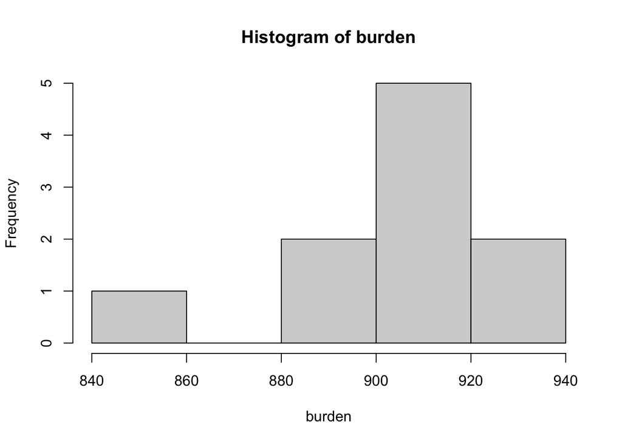

```r
tips=PDD$SDS8$pdx$meta$clones_short
tree=PDD$SDS8$pdx$tree_ml
burden=nodeHeights(tree)[match(match(tips,tree$tip.label),tree$edge[,2]),2]
hist(burden)
```

```r
burden=mean(burden)
cat("Mean burden=",burden,"\n")
```

```
## Mean burden= 905.3996
```

```r
pn=2*min(pnbinom(burden,mu=496,size=496/(ODF-1),lower.tail = FALSE),
         pnbinom(burden,mu=496,size=496/(ODF-1),lower.tail = TRUE))
cat("Negative Binomial based two sided p-value",pn)
```

```
## Negative Binomial based two sided p-value 3.54504e-25
```

```r
##  Recalculate using the upper end of the predicted over dispersion range
pn=2*min(pnbinom(burden,mu=496,size=496/(ODF_MAX-1),lower.tail = FALSE),
         pnbinom(burden,mu=496,size=496/(ODF_MAX-1),lower.tail = TRUE))
cat("Negative Binomial based two sided p-value",pn)
```

```
## Negative Binomial based two sided p-value 9.834756e-21
```